# IODS course project

# Introduction to Open Data Science - Course Project

# About the project

*Write a short description about the course and add a link to your GitHub repository here. This is an R Markdown (.Rmd) file so you should use R Markdown syntax.*

```r
# This is a so-called "R chunk" where you can write R code.

date()
```

```
## [1] "Fri Dec  4 00:24:41 2020"
```

The text continues here.

[Link to my Github repo](https://github.com/LeonMercier/IODS-project)

It will be interesting to see where this course goes. I’ve been learning R on at my own pace for some time now, working on my own data and learning in a very unstructured way. I’ve learnt a lot but it has taken me a long time to do simple analyses. But that is learning I guess.

When it comes to statistics, I’m quite bad and I hope really that I can keep up with the exercises.

I hope the skills learned on this course will help me work more efficiently but also to improve the **reproducibility** of my work. It seems to me that the more I learn about reproducibility, the worse the current situation in published science looks like. Data related methods are often shared in a very superficial way and the data itself is still only rarely made public.

## Pushing to Git from Rstudio

1. knit index.Rmd
2. from Git tab; commit
3. tick each box and write commit message
4. commit
5. push

# Week 2: regression and model validation

*Describe the work you have done this week and summarize your learning.*

- Describe your work and results clearly.
- Assume the reader has an introductory course level understanding of writing and reading R code as well as statistical methods.
- Assume the reader has no previous knowledge of your data or the more advanced methods you are using.

```r
date()
```

```
## [1] "Fri Dec  4 00:24:41 2020"
```

## First some notes from the DataCamp exercises

the actual analysis exercise is further down

We can use a character vector to hold variable names, but then we need to use all_of() inside of select()

```r
vars <- c("var1", "var2", "var3")
analysis <- select(df, all_of(vars))
```

The syntax for renaming variables is rename(df, newName = oldName) no quotes

```r
rename(learning2014, dEEp = deep)
```

- filter() is like subset()
- geom_smooth() is used to add regression lines to plots
- pairs() a quick graphical comparison of all possible variable pairs in a data frame
- ggpairs() is same as pairs() but more advanced
  - with the ‘upper’ and ‘lower’ parameters it can be useful to use wrap()

## A couple of notes from the MABS4IODS book

On interpreting the p-value:

> The probability of obtaining the observed data (or data that represent a more extreme departure from the null hypothesis) if the null hypothesis is true.

and

> p-values should not be taken too seriously; confidence intervals are often more informative

Terminology:

response variable = intercept + (slope * explanatory var) + error

## More notes from the DataCamp exercises

### Video: Linear regression

Residuals: the difference between values predicted by the model and the actual values of the response variable *y*. The model is found by minimizing the sum of the squared residuals (distances of the data points from the regression line)

Meaning of the output of summary() * coefficients: estimates of the model parameters  
* intercept estimate: alpha of model * variable estimate: beta or slope of model * t-value and p-value testing the null hypothesis that the slope is 0 (no relationship between variables) * low p-value: we can conclude that there *IS* a relationship between the variables

Regression model object is created with lm() and it can also be multivariable (x1, x2, x3 …)  
Conveniently passing the object to plot() gives diagnostic plots

```r
my_lm <- lm(y ~ x1 + x2 + x3 ..., data = df)
plot(my_lm)
```

### Video: Model validation

The assumption of the model must be confirmed to be true before it should be trusted. Considering the residuals / errors, this means that (number 3 and 4 are essentially the same thing?): 1) errors are normally distributed 2) errors are not correlated 3) errors have constant variance 4) error size does not depend on explanatory variable

So how to examine this?  
* Normal distribution of residuals: the QQ-plot * Residuals are normally distributed if they fall on the line of the plot * Constant variance of errors = error size does not depend on explanatory variable * Plot residuals vs model predictions/fitted values * There should not be any kind of pattern * Leverage means how much impact a single observation has on the model * Plot residuals vs leverage and you will see which observations have an unusually high impact

The lm-object we created can be used to predict using and existing model: giving new values for the explanatory variable, we can predict the dependent variable

```r
predict(existing_model, newdata = df)
```

## And here goes the analysis part of the 2nd week assignement

First we load the required libraries that we use in addition to the built-in R functions

```r
library(GGally)
```

```r
library(ggplot2)
```

Then we read the already wrangled data from a file

```r
students2014 <- read.csv("data/learning2014.csv")
```

The data has 166 rows and 7 column, which correspond to 166 students surveyed and 7 variables measured for each.

```r
dim(students2014)
```

```
## [1] 166   7
```

The Attitude, deep, stra and surf variables range from 1 to 5, they were created by taking the means of several answers to a questionnaire.

```r
str(students2014)
```

```
## 'data.frame':    166 obs. of  7 variables:
##  $ gender  : chr  "F" "M" "F" "M" ...
##  $ Age     : int  53 55 49 53 49 38 50 37 37 42 ...
##  $ attitude: num  3.7 3.1 2.5 3.5 3.7 3.8 3.5 2.9 3.8 2.1 ...
##  $ deep    : num  3.58 2.92 3.5 3.5 3.67 ...
##  $ stra    : num  3.38 2.75 3.62 3.12 3.62 ...
##  $ surf    : num  2.58 3.17 2.25 2.25 2.83 ...
##  $ Points  : int  25 12 24 10 22 21 21 31 24 26 ...
```

We can better understand the data by drawing some exploratory plots. The aesthetic aes() is used to color the plots according to gender (col) and set a transparency (alpha). The wrap() function is used to set the function and parameter used by ggpairs to draw the plots.

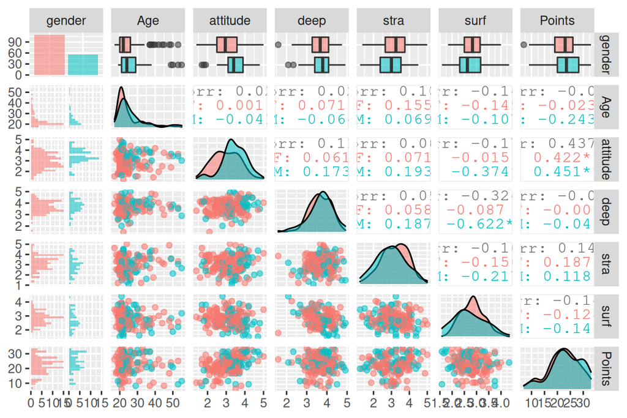

```r
p <- ggpairs(students2014, mapping = aes(col = gender, alpha = 0.4), lower = list(combo = wrap("facethist", bins = 20)))
# draw the plot
p
```

Then comes the actual regression modeling. Attitude, stra and surf were chosen as the explanatory variables as they showed the highest correlations to Points in the exploratory plots above.

```r
lm <- lm(Points ~ attitude + stra + surf, data = students2014)
```

Then we examine the model we made:

```r
summary(lm)
```

```
##
## Call:
## lm(formula = Points ~ attitude + stra + surf, data = students2014)
##
## Residuals:
##      Min       1Q   Median       3Q      Max
## -17.1550  -3.4346   0.5156   3.6401  10.8952
##
## Coefficients:
##             Estimate Std. Error t value Pr(>|t|)
## (Intercept)  11.0171     3.6837   2.991  0.00322 **
## attitude      3.3952     0.5741   5.913 1.93e-08 ***
## stra          0.8531     0.5416   1.575  0.11716
## surf         -0.5861     0.8014  -0.731  0.46563
## ---
## Signif. codes:  0 '***' 0.001 '**' 0.01 '*' 0.05 '.' 0.1 ' ' 1
##
## Residual standard error: 5.296 on 162 degrees of freedom
## Multiple R-squared:  0.2074, Adjusted R-squared:  0.1927
## F-statistic: 14.13 on 3 and 162 DF,  p-value: 3.156e-08
```

We see that the coefficients for stra and surf have high p-values, in other words not statistically significant, so lets remove them (this should give the most parsimonious model)

```r
lm <- lm(Points ~ attitude, data = students2014)
summary(lm)
```

```
##
## Call:
## lm(formula = Points ~ attitude, data = students2014)
##
## Residuals:
##      Min       1Q   Median       3Q      Max
## -16.9763  -3.2119   0.4339   4.1534  10.6645
##
## Coefficients:
##             Estimate Std. Error t value Pr(>|t|)
## (Intercept)  11.6372     1.8303   6.358 1.95e-09 ***
## attitude      3.5255     0.5674   6.214 4.12e-09 ***
## ---
## Signif. codes:  0 '***' 0.001 '**' 0.01 '*' 0.05 '.' 0.1 ' ' 1
##
## Residual standard error: 5.32 on 164 degrees of freedom
## Multiple R-squared:  0.1906, Adjusted R-squared:  0.1856
## F-statistic: 38.61 on 1 and 164 DF,  p-value: 4.119e-09
```

Then we generate some diagnostic plots to check if the model assumptions are correct. Calling plot() on a lm-object will call lm.plot(), meaning we can use the which option to select plot types. The par() function puts the plots in a nice grid.

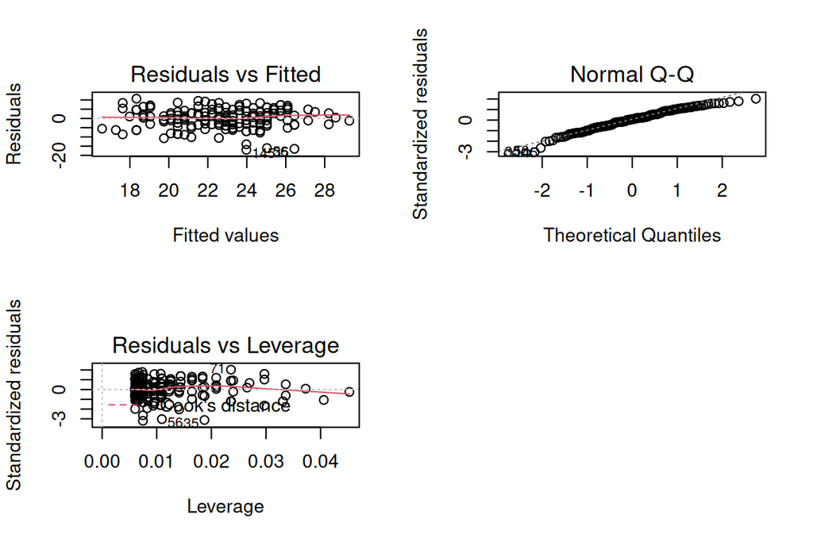

```r
par(mfrow = c(2,2))
plot(lm, which = c(1,2,5))
```

(more chapters to be added similarly as we proceed with the course!)

# Week 3

## Lesson monday 2020-11-09

generalized linear models: works also for example for binary response variables

```r
library(tidyverse)
alc <- read.csv("data/alc.csv")
colnames(alc)
```

```
##  [1] "school"     "sex"        "age"        "address"    "famsize"
##  [6] "Pstatus"    "Medu"       "Fedu"       "Mjob"       "Fjob"
## [11] "reason"     "nursery"    "internet"   "guardian"   "traveltime"
## [16] "studytime"  "failures"   "schoolsup"  "famsup"     "paid"
## [21] "activities" "higher"     "romantic"   "famrel"     "freetime"
## [26] "goout"      "Dalc"       "Walc"       "health"     "absences"
## [31] "G1"         "G2"         "G3"         "alc_use"    "high_use"
```

Quick way to plot counts of a lot of variables

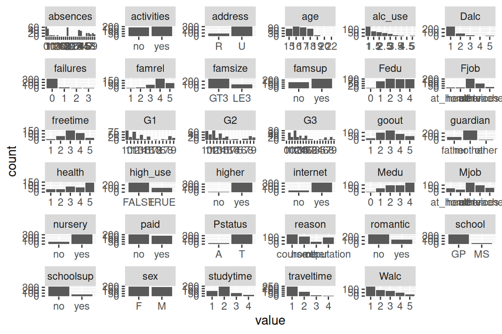

```r
gather(alc) %>% ggplot(aes(value)) + facet_wrap("key", scales = "free") + geom_bar()
```

## Datacamp video; logistic regression

## Datacamp video; odds ratio

odds ratio = odds of Y=1 when has property X / odds of Y=1 when has NO X

“study the relationships between high/low alcohol consumption and some of the other variables in the data. To do this, choose 4 interesting variables in the data and for each of them, present your personal hypothesis about their relationships with alcohol consumption.” 1) freetime: more free time leads to higher alcohol use 2) goout: going out leads to higher alcohol use 3) address: students with rural home environments drink less 4) Medu: students with highly educated mothers drink less

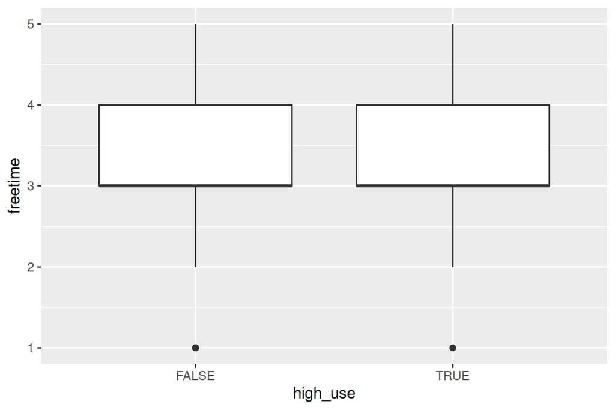

```r
g1 <- ggplot(alc, aes(x = high_use, y = freetime))
g1 + geom_boxplot()
```

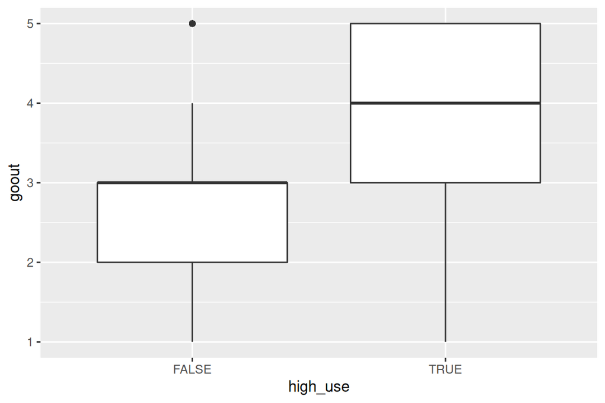

```r
g2 <- ggplot(alc, aes(x = high_use, y = goout))
g2 + geom_boxplot()
```

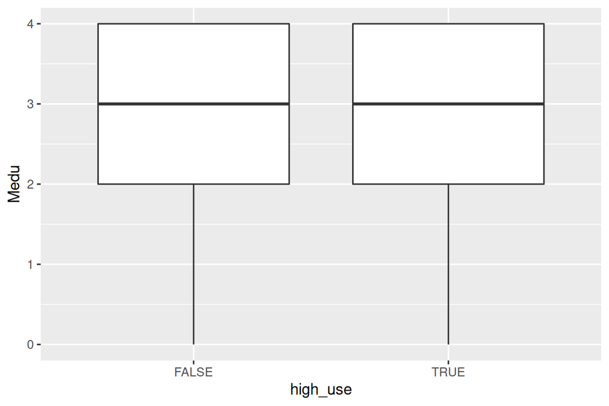

```r
g4 <- ggplot(alc, aes(x = high_use, y = Medu))
g4 + geom_boxplot()
```

```r
with(alc, table(high_use, address))
```

```
##         address
## high_use   R   U
##    FALSE  50 218
##    TRUE   31  83
```

## the model:

```r
m <- glm(high_use ~ freetime + goout + Medu + address, data = alc, family = "binomial")
# compute odds ratios (OR)
OR <- coef(m) %>% exp

# compute confidence intervals (CI)
CI <- confint(m) %>% exp
# print out the odds ratios with their confidence intervals
cbind(OR, CI)
```

```
##                     OR      2.5 %    97.5 %
## (Intercept) 0.04015697 0.01159821 0.1290620
## freetime    1.13515481 0.87658190 1.4734760
## goout       2.11867002 1.67944424 2.7101335
## Medu        1.01405916 0.81179751 1.2702288
## addressU    0.48689142 0.27329731 0.8678783
```

# Week 4

# Week 5

## Notes from DataCamp exercises

complete.cases() returns true if case has no NAs

correlation matrix cor() correlation plot: cor(df) %>% corplot()

Video: dimensionality reduction techniques dimensionality ~~ number of variables per observation

PCA components are uncorrelated to eachother 1st captures most variance, 2nd most of remaining variance etc. -> *Order of importance* assumes that features(variables) with mre variance are more important -> standardization of data

“There are two functions in the default package distribution of R that can be used to perform PCA: princomp() and prcomp(). The prcomp() function uses the SVD and is the preferred, more numerically accurate method.”

standardization of data: scale()

prcomp(df) %>% biplot()

-> scatter plot of observations according to PC1 and PC2 arrows represet the original features -> pointing same way = pos. correlation -> 90 deg angle = no correlation -> pointing same way as axis: correlated to the PC

Multiple correspondence analysis (MCA): like PCA but for categorical variables

## Then onto the actual course exercise

First we load the required packages. Tidyverse includes dplyr and others.

```r
library(tidyverse)
library(GGally)
```

Then we read the data from a file, make a visualisation showing possible correlations of the variables. And finally we show summary of the variables.

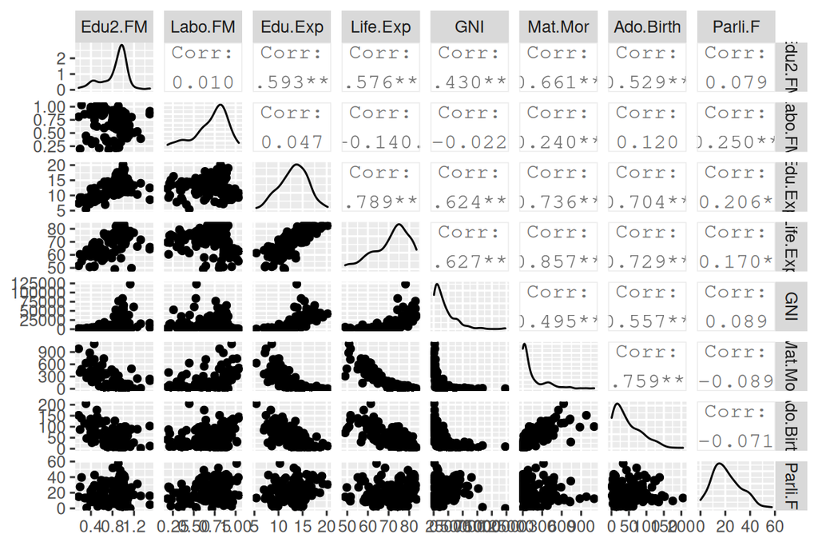

```r
# row.names = 1 means that the first column is interpreted as rownames
human <- read.csv("data/human.csv", row.names = 1)
ggpairs(human)
```

```r
summary(human)
```

```
##     Edu2.FM          Labo.FM          Edu.Exp         Life.Exp
##  Min.   :0.1717   Min.   :0.1857   Min.   : 5.40   Min.   :49.00
##  1st Qu.:0.7264   1st Qu.:0.5984   1st Qu.:11.25   1st Qu.:66.30
##  Median :0.9375   Median :0.7535   Median :13.50   Median :74.20
##  Mean   :0.8529   Mean   :0.7074   Mean   :13.18   Mean   :71.65
##  3rd Qu.:0.9968   3rd Qu.:0.8535   3rd Qu.:15.20   3rd Qu.:77.25
##  Max.   :1.4967   Max.   :1.0380   Max.   :20.20   Max.   :83.50
##       GNI            Mat.Mor         Ado.Birth         Parli.F
##  Min.   :   581   Min.   :   1.0   Min.   :  0.60   Min.   : 0.00
##  1st Qu.:  4198   1st Qu.:  11.5   1st Qu.: 12.65   1st Qu.:12.40
##  Median : 12040   Median :  49.0   Median : 33.60   Median :19.30
##  Mean   : 17628   Mean   : 149.1   Mean   : 47.16   Mean   :20.91
##  3rd Qu.: 24512   3rd Qu.: 190.0   3rd Qu.: 71.95   3rd Qu.:27.95
##  Max.   :123124   Max.   :1100.0   Max.   :204.80   Max.   :57.50
```

Looking at the plots, it seems quite clear that several of the variables are correlated. For example Gross National income has a positive correlation to expected length of schooling, life expectancy and ratio of women in higher education. Additionally, it has a negative correlation to maternal mortality and adolescent birth ratio. Most variables seem to have a somewhat normal distribution with some having a long one-sided tail; most countries rank on the low side of the spectrum in GNI, maternal mortality and adolescent births with the distributions having only a few very high values.

We use prcomp() to make the principal component analysis and biplot() to visualise the result. Then we show the amount of variability captured by each principal component, converted into percentage display.

```r
pca <- prcomp(human)
round(100 * summary(pca)$importance[2,], digits = 2)
```

```
##   PC1   PC2   PC3   PC4   PC5   PC6   PC7   PC8
## 99.99  0.01  0.00  0.00  0.00  0.00  0.00  0.00
```

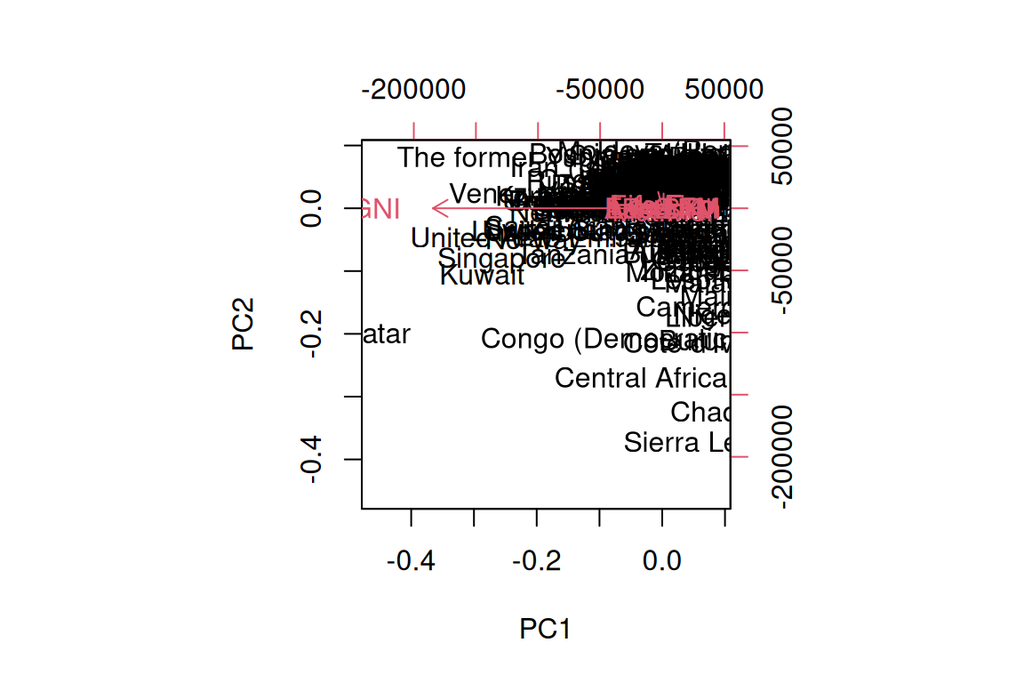

```r
biplot(pca)
```

This plot is a mess. Here we see that with the non-standardized data the first principal component captures nearly all of the variability of the data. This is due to the variances of the variables being of different sizes.

And we do the same as above but with properly scaled (standardized data). This means that the variables have equal means and standard deviations. This is required because the principal component analysis heavily emphasizes variables with a higher variance. Here in the above example GNI is emphasized because its numeric values are much higher than those of the other variables.

```r
humanStd <- scale(human)
pca <- prcomp(humanStd)
round(100 * summary(pca)$importance[2,], digits = 2)
```

```
##   PC1   PC2   PC3   PC4   PC5   PC6   PC7   PC8
## 53.61 16.24  9.57  7.58  5.48  3.60  2.63  1.30
```

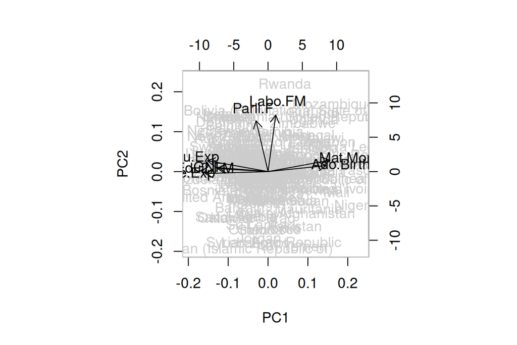

```r
biplot(pca, col = c("grey80", "black"), expand = 1)
```

Here we see that that the variables Edu.Exp, Edu2.FM, Life.exp, GNI, Mat.Mor and Ado.Birth are along the X-axis representing PC1. Mat.Mor and Ado.Birth are pointing to an opposite direction compared to the rest of the variables indicating an inverse correlation. This makes sense intuitively: countries with high level of wealth, educational expectation and life exectancy have low maternal mortality and adolescent births. The arrows representing Parl.F and Labo.FM are along the Y-axis. They represent PC2, having a very low correlation to the PC1 variables. These variables indicate the level of gender equality in the labour market and in the parliaments of the countries. So the main result of our analysis is that women’s empowerment is not necessarily correlated to more conventional measurements of human progress. There may be countries with a high level of wealth but where women do not have equal standing in society and likewise there may be countries that are more egalitarian, but poor with low level of education and health services. What is odd though is that the variable Edu2.FM seems not to follow this pattern, suggesting women’s proportion in secondary education is more related to the wealth of the country than to the level of gender equality in that country.

### Multiple correspondence analysis

We load the FactoMineR library and the ‘tea’ dataset. Then we explore the structure and dimensions of the dataset.

```r
library(FactoMineR)
data(tea)
str(tea)
```

```
## 'data.frame':    300 obs. of  36 variables:
##  $ breakfast       : Factor w/ 2 levels "breakfast","Not.breakfast": 1 1 2 2 1 2 1 2 1 1 ...
##  $ tea.time        : Factor w/ 2 levels "Not.tea time",..: 1 1 2 1 1 1 2 2 2 1 ...
##  $ evening         : Factor w/ 2 levels "evening","Not.evening": 2 2 1 2 1 2 2 1 2 1 ...
##  $ lunch           : Factor w/ 2 levels "lunch","Not.lunch": 2 2 2 2 2 2 2 2 2 2 ...
##  $ dinner          : Factor w/ 2 levels "dinner","Not.dinner": 2 2 1 1 2 1 2 2 2 2 ...
##  $ always          : Factor w/ 2 levels "always","Not.always": 2 2 2 2 1 2 2 2 2 2 ...
##  $ home            : Factor w/ 2 levels "home","Not.home": 1 1 1 1 1 1 1 1 1 1 ...
##  $ work            : Factor w/ 2 levels "Not.work","work": 1 1 2 1 1 1 1 1 1 1 ...
##  $ tearoom         : Factor w/ 2 levels "Not.tearoom",..: 1 1 1 1 1 1 1 1 1 2 ...
##  $ friends         : Factor w/ 2 levels "friends","Not.friends": 2 2 1 2 2 2 1 2 2 2 ...
##  $ resto           : Factor w/ 2 levels "Not.resto","resto": 1 1 2 1 1 1 1 1 1 1 ...
##  $ pub             : Factor w/ 2 levels "Not.pub","pub": 1 1 1 1 1 1 1 1 1 1 ...
##  $ Tea             : Factor w/ 3 levels "black","Earl Grey",..: 1 1 2 2 2 2 2 1 2 1 ...
##  $ How             : Factor w/ 4 levels "alone","lemon",..: 1 3 1 1 1 1 1 3 3 1 ...
```

[output cut: 22 more lines]

```r
dim(tea)
```

```
## [1] 300  36
```

Let’s make some kind of visualisation

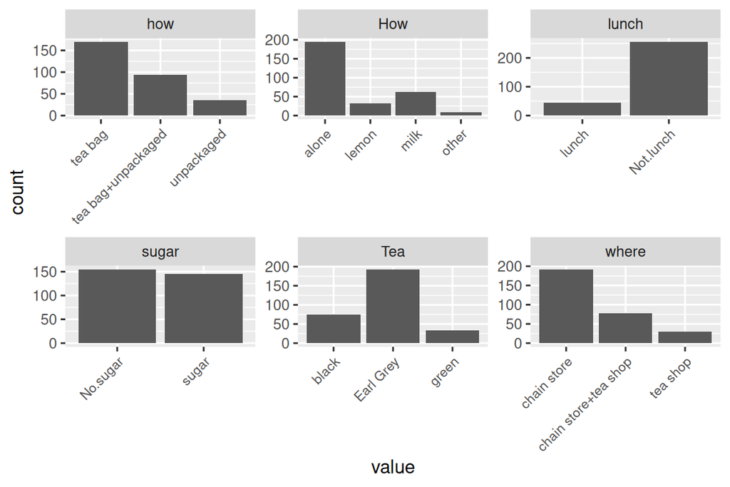

```r
# these are the columns we want
keep_columns <- c("Tea", "How", "how", "sugar", "where", "lunch")
# create a new dataFrame with only the desired columns
tea_time <- select(tea, all_of(keep_columns))

gather(tea_time) %>% ggplot(aes(value)) + facet_wrap("key", scales = "free") + geom_bar() +theme(axis.text.x = element_text(angle = 45, hjust = 1, size = 8))
```

Performing the Multiple correspondence analysis.

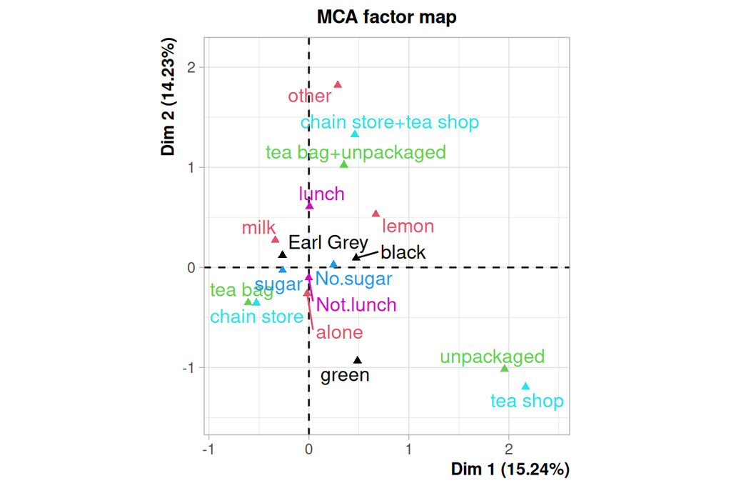

```r
#suppress the automatic graphing of mca(); we make a custom plot below
mca <- MCA(tea_time, graph = FALSE)
plot(mca, invisible = c("ind"), habillage = "quali")
```

It seems that the packaging of tea and the place of purchase are correlated. For example, individuals who buy tea from tea shops also tend to buy unpackaged tea. Fans of green tea also seem to be more likely to be in the teashop/unpackaged group. These are reasonable conclusion if looking at the tea selection in supermarkets; it is mostly black tea packaged in teabags. With the other variables correlations are less clear.

# Week 6

gather()